# hw6

**Автор - Федоров А. Н.**  
*Выводы промежуточных клеток удалены для краткости.*

```python
import rdkit
from rdkit import Chem
from rdkit.Chem import AllChem, Draw
from rdkit.Chem import Descriptors
from rdkit import RDConfig
from IPython.display import Image,display
import numpy as np
import base64
from IPython.display import HTML, display

import numpy as np
import seaborn as sns
import matplotlib.pyplot as plt
```

### Подготовка файла координат и файла топологии.

```python
# gro файл с координатами этана
!wget http://kodomo.fbb.msu.ru/FBB/year_08/term6/etane.gro
```

Найдем в atomtypes.atp корректные значения для колонки type в et.top:

```python
!cat /usr/share/gromacs/top/oplsaa.ff/atomtypes.atp | grep "alkane C"
```

```
 opls_135   12.01100  ; alkane CH3
 opls_136   12.01100  ; alkane CH2
 opls_137   12.01100  ; alkane CH
 opls_138   12.01100  ; alkane CH4
 opls_139   12.01100  ; alkane C
```

```python
!cat /usr/share/gromacs/top/oplsaa.ff/atomtypes.atp | grep "alkane H"
```

```
 opls_140    1.00800  ; alkane H.
```

```python
mol = Chem.MolFromSmiles('CC')
AllChem.Compute2DCoords(mol)
m3d = Chem.AddHs(mol)
Chem.AllChem.EmbedMolecule(m3d)
AllChem.MMFFOptimizeMolecule(m3d, maxIters=500, nonBondedThresh=200)
```

```
0
```

```python
bonds = []
for b in m3d.GetBonds():
    bonds.append(
    f'{b.GetBeginAtomIdx() + 1:>5}{b.GetEndAtomIdx() + 1:>5}{1:>5}'
    )
bonds = "\n".join(bonds)
print(bonds)
```

```
    1    2    1
    1    3    1
    1    4    1
    1    5    1
    2    6    1
    2    7    1
    2    8    1
```

```python
angles = []

for b1 in m3d.GetBonds():
    for b2 in m3d.GetBonds():
        if b1.GetBeginAtomIdx() == b2.GetBeginAtomIdx() and b1.GetIdx() != b2.GetIdx():
            bond = b1.GetEndAtomIdx() + 1, b1.GetBeginAtomIdx() + 1, b2.GetEndAtomIdx() + 1
            if bond not in angles and bond[::-1] not in angles:
                angles.append(bond)
angles = "\n".join(f"{a:>5}{b:>5}{c:>5}{1:>5}" for a, b, c in angles)
print(angles)
```

```
    2    1    3    1
    2    1    4    1
    2    1    5    1
    3    1    4    1
    3    1    5    1
    4    1    5    1
    6    2    7    1
    6    2    8    1
    7    2    8    1
```

```python
dihedrals = []
for b1 in m3d.GetBonds():
    for b2 in m3d.GetBonds():
        for b3 in m3d.GetBonds():
             if b1.GetBeginAtomIdx() == b2.GetBeginAtomIdx() and \
                b1.GetIdx() != b2.GetIdx() and \
                b2.GetEndAtomIdx() == b3.GetBeginAtomIdx():
                dihedrals.append(
                    f"{b1.GetEndAtomIdx() + 1:>5}{b1.GetBeginAtomIdx() + 1:>5}"
                    f"{b2.GetEndAtomIdx() + 1:>5}{b3.GetEndAtomIdx() + 1:>5}{3:>5}"
                )
dihedrals = "\n".join(dihedrals)
print(dihedrals)
```

```
    3    1    2    6    3
    3    1    2    7    3
    3    1    2    8    3
    4    1    2    6    3
    4    1    2    7    3
    4    1    2    8    3
    5    1    2    6    3
    5    1    2    7    3
    5    1    2    8    3
```

```python
template = f"""#include "/usr/share/gromacs/top/oplsaa.ff/forcefield.itp"

[ moleculetype ]
; Name            nrexcl
et            3

[ atoms ]
;   nr  type  resnr  residue  atom   cgnr     charge       mass
    1   opls_139      1    ETH      C1      1    -0.189      12.01
    2   opls_139      1    ETH      C2      2    -0.155      12.01
    3   opls_140      1    ETH      H1      3     0.0059       1.008
    4   opls_140      1    ETH      H2      4     0.0059       1.008
    5   opls_140      1    ETH      H3      5     0.0059       1.008
    6   opls_140      1    ETH      H4      6     0.0056       1.008
    7   opls_140      1    ETH      H5      7     0.0056       1.008
    8   opls_140      1    ETH      H6      8     0.0056       1.008

[ bonds ]
;  ai    aj funct  b0       kb
{bonds}

[ angles ]
;  ai    aj    ak funct  phi0   kphi
{angles}

[ dihedrals ]
{dihedrals}

[ pairs ]
; список атомов 1-4
;  ai    aj funct
   3  6
   3  7
   3  8
   4  6
   4  7
   4  8
   5  6
   5  7
   5  8

[ System ]
; any text here
first one
[ molecules ]
;Name count
 et    1
"""

with open("et.top", 'w') as file:
    file.write(template)
```

### Моделирование

Проведем моделирование и сразу подготовим все данные для дальнейшего анализа.

```python
methods = [
    ("http://kodomo.fbb.msu.ru/FBB/year_08/term6/be.mdp", "be", "Берендсена"),
    ("http://kodomo.fbb.msu.ru/FBB/year_08/term6/vr.mdp", "vr", "Velocity rescale"),
    ("http://kodomo.fbb.msu.ru/FBB/year_08/term6/nh.mdp", "nh", "Нуза-Хувера"),
    ("http://kodomo.fbb.msu.ru/FBB/year_08/term6/an.mdp", "an", "Андерсена"),
    ("http://kodomo.fbb.msu.ru/FBB/year_08/term6/sd.mdp", "sd", "стохастической молекулярной динамики")
]
```

```python
%%writefile b.ndx

[ b ]
1 2
```

```
Overwriting b.ndx
```

```python
for url, nick, name in methods:
    print("Обработка метода ", name)
    !wget -O {nick}.mdp {url}
    !grompp -f {nick}.mdp -c etane.gro -p et.top -o et_{nick}.tpr
    !mdrun -deffnm et_{nick} -v -nt 1
    !echo "0" | trjconv -f et_{nick}.trr -s et_{nick}.tpr -o et_{nick}.pdb
    !echo "10" | g_energy -f et_{nick}.edr -o et_{nick}_pot_en.xvg -xvg none
    !echo "11" | g_energy -f et_{nick}.edr -o et_{nick}_kin_en.xvg -xvg none
    !g_bond -f et_{nick}.trr -s et_{nick}.tpr -o bond_{nick}.xvg -n b.ndx -xvg none
```

### Визуальный анализ

Начнем с полученных pdb. Для простоты, рендер видео я сделал на локальной машине c помощью следующего кода:

```python
import sys
import pymol

_stdouterr = sys.stdout, sys.stderr
pymol.finish_launching(['pymol', '-q'])
sys.stdout, sys.stderr = _stdouterr

from pymol import cmd, movie
```

```python
for _, nick, _ in methods:
    cmd.reinitialize()
    cmd.load(f'et_{nick}.pdb')
    cmd.set('ray_trace_frames', '1')
    cmd.set('ray_trace_mode', '1')

    !mkdir -p frames

    cmd.mpng('./frames/movie')
    input("Rendering...")

    !ffmpeg -y -i './frames/movie%04d.png' -c:v libx264 -pix_fmt yuv420p -vf "crop=trunc(iw/2)*2:trunc(ih/2)*2" {nick}.mp4 > /dev/null
    !rm -rf frames
```

Полученные видео я вручную загрузил на shadbox. Имеем следующее:

```python
def embedmp4(video):
    with open(video, "rb") as video:
        video = base64.b64encode(video.read())
    return HTML(
        f'<video controls alt="PyMol Movie" src="data:video/mp4;base64,{video.decode()}" type="video/mp4">'
    )
```

```python
for _, nick, name in methods:
    display(HTML(f"<h4>Метод {name}</h4><br>"))
    display(embedmp4(f"{nick}.mp4"))
```

Метод Берендсена

[video not shown]

Метод Velocity rescale

[video not shown]

Метод Нуза-Хувера

[video not shown]

Метод Андерсена

[video not shown]

Метод стохастической молекулярной динамики

[video not shown]

Выглядят результаты моделирования, мягко говоря, хаотично интересно. Можно отметить:

- Метод Андерсена дает самую устойчивую картинку, колеблется только длина связи С-С.
- Метод стохастической молекулярной динамики оправдывает свое название. Можно наблюдать наиболее хаотичное вращения молекулы.
- Метод Нуза-Хувера и Velocity rescale похожи, в обоих случаях значительная доля вращения приходится на связь C-C.

### Анализ потенциальной и кинетической энергии

Для наглядности все графики нарисуем в одном масштабе.

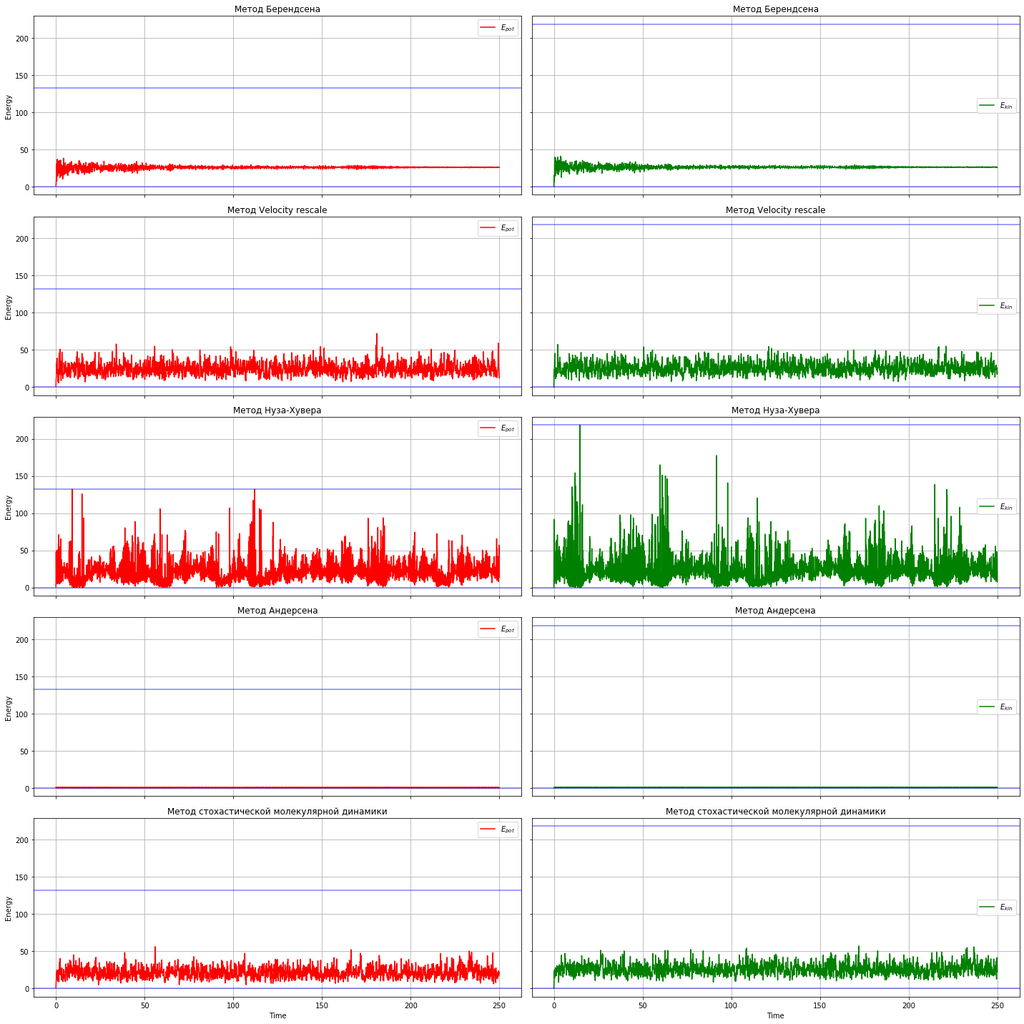

```python
fig, axes = plt.subplots(len(methods), 2, sharex=True, sharey=True, figsize=(20, 20))

# нарисуем красивые линии с наблюдаемым минимумом и максимумом
minpot, maxpot = float("inf"), float("-inf")
minkin, maxkin = float("inf"), float("-inf")

for ind, (_, nick, name) in enumerate(methods):
    potent = np.loadtxt(f"et_{nick}_pot_en.xvg")
    kinetic = np.loadtxt(f"et_{nick}_kin_en.xvg")

    minpot, maxpot = min(minpot, *potent[:, 1]), max(maxpot, *potent[:, 1])
    minkin, maxkin = min(minkin, *kinetic[:, 1]), max(maxkin, *kinetic[:, 1])

    ax = axes[ind]

    for ax, toplot, label, color in zip(axes[ind], [potent, kinetic], ["$E_{pot}$", "$E_{kin}$"], ['r', 'g']):
        ax.set_title(f"Метод {name}")
        sns.lineplot(x=toplot[:, 0], y=toplot[:, 1], label = label, color=color, ax=ax)
        ax.set_xlabel("Time")
        ax.set_ylabel("Energy")
        ax.grid()
        ax.legend()

for row in axes:
    row[0].axhline(y=minpot, color='blue', alpha=0.5)
    row[0].axhline(y=maxpot, color='blue', alpha=0.5)
    row[1].axhline(y=minkin, color='blue', alpha=0.5)
    row[1].axhline(y=maxkin, color='blue', alpha=0.5)

fig.tight_layout()
```

Наблюдения:

- График изменения энергии в методе Velocity rescale больше всего похож на метод стохастической МД, а не на метод Нуза-Хувера. Что противоречит визуальным выводам.
- Метод Андерсена наиболее консервативен, что согласуется с PyMol визуализацией.
- Метод Нуза-Хувера показывает самые большие колебания энергии, хотя, по прошлой визуализации, я бы ожидал такого поведения от метода стохастической МД.
- Дисперсия энергии в методе Берендсена со временем сильно падает. Если обратиться к визуализации - это выглядит как переход к цикличной траектории вращения.

### Анализ длины связи С-С

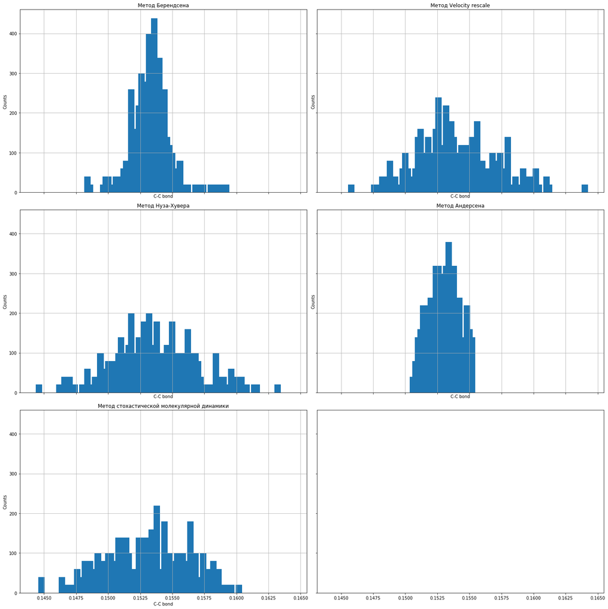

```python
fig, axes = plt.subplots(3, 2, sharex=True, sharey=True, figsize=(20, 20))
axes = axes.ravel()

for ind, (_, nick, name) in enumerate(methods):
    ax = axes[ind]

    bond = np.loadtxt(f'bond_{nick}.xvg')
    ax.bar(bond[:, 0], bond[:, 1], 0.0005)

    ax.set_title(f"Метод {name}")
    ax.set_xlabel("C-C bond")
    ax.set_ylabel("Counts")
    ax.grid()

fig.tight_layout()
```

Наблюдения:

- Почти все распределения длин связи так или иначе напоминают нормальное.
- Самыми консервативными являются методы Андерсена и Берендсена. Как по графику энергии, так и по дисперсии распределения длины связи.

### Выводы

*Учитывая форму распределения Больцмана и все Ваши наблюдения сделайте вывод о том какой из методов позволяет наиболее реалистично поддерживать температуру в системе. Опишите найденные Вами недостатки предложенных алгоритмов. Постройте таблицу зависимости быстродействия от алгоритма.*

Дополнительно построим распределение кинетической энергии в нашей системе для каждого случая. Это не скорости, но они должны напоминать распределение Больцмана (они ~v^2, если я хоть что-то понимаю в физике и химии):

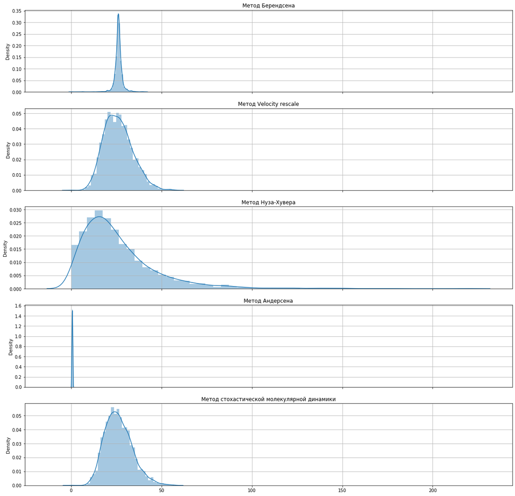

```python
import warnings
warnings.simplefilter("ignore")

fig, axes = plt.subplots(len(methods), 1, sharex=True, figsize=(20, 20))
axes = axes.ravel()

for ind, (_, nick, name) in enumerate(methods):
    kinetic = np.loadtxt(f"et_{nick}_kin_en.xvg")

    ax = axes[ind]
    sns.distplot(kinetic[:, 1], ax=ax)
    ax.set_title(f"Метод {name}")
    ax.set_ylabel("Density")
    ax.grid()
```

Сложно однозначно сказать какой из методов позволяет наиболее реалистично поддерживать температуру в системе. Если верить мануалу GROMACS, каждый из подходов работает, но у них есть своя область применения.

Конкретно для нашей системы с одной молекулой, кажется, хорошим приближением будет метод стохастической МД, либо метод Velosity rescale. Остальные термостаты либо совокупно переоценивают динамику системы (Нуза-Хувера), либо недооценивают ее (Берендсена, Андерсена).

Строить зависимость быстродействия от алгоритма почти нет смысла, т.к. у нас система из одной молекулы и разница составляет доли секунды. Разницу нужно смотреть именно на больших системах.

```python
speed = [3.043, 3.236, 3.258, 3.063, 3.631]
for s, (_, _, name) in zip(speed, methods):
    print(f"{s:<5}s - метод {name}")
```

```
3.043s - метод Берендсена
3.236s - метод Velocity rescale
3.258s - метод Нуза-Хувера
3.063s - метод Андерсена
3.631s - метод стохастической молекулярной динамики
```

```python
!jupyter nbconvert hw6.ipynb --to html
```

```
[NbConvertApp] Converting notebook hw6.ipynb to html
[NbConvertApp] Writing 3966674 bytes to hw6.html
```